# Stat 3701 Lecture Notes: Data

Charles J. Geyer

April 07, 2020

> The combination of some data and an aching desire for an answer does not ensure that a reasonable answer can be extracted from a given body of data.

> — John W. Tukey (the first of six “basics” against statistician’s hubrises) in “Sunset Salvo”, *American Statistician*, 40, 72–76 (1986).

[figure not shown]

xkcd:1781 Artifacts

# 1 License

This work is licensed under a Creative Commons Attribution-ShareAlike 4.0 International License (http://creativecommons.org/licenses/by-sa/4.0/).

# 2 R

- The version of R used to make this document is 3.6.3.
- The version of the `rmarkdown` package used to make this document is 2.1.
- The version of the `MASS` package used to make this document is 7.3.51.5.
- The version of the `quantreg` package used to make this document is 5.54.
- The version of the `XML` package used to make this document is 3.99.0.3.
- The version of the `jsonlite` package used to make this document is 1.6.1.
- The version of the `RSQLite` package used to make this document is 2.2.0.
- The version of the `DBI` package used to make this document is 1.1.0.

# 3 Data

## 3.1 Data Frames

Statistics or “data science” starts with data. Data can come in many forms but it often comes in a data frame — or at least something R can turn into a data frame. As we saw at the end of the handout about matrices, arrays, and data frames, the two R functions most commonly used to input data into data frames are `read.table` and `read.csv`. We will see some more later.

## 3.2 Data Artifacts, Errors, Problems

### 3.2.1 Introduction

> Anything which uses science as part of its name isn’t: political science, creation science, computer science.

> — [Hal Abelson](https://en.wikipedia.org/wiki/Hal_Abelson)

Presumably he would have added “data science” if the term had existed when he said that. Statistics doesn’t get off lightly either because of the journal [*Statistical Science*](http://imstat.org/sts/).

It is the dirty little secret of science, business, statistics, and “data science” is that there are a lot of errors in almost all data when they get to a data analyst, whatever his or her job title may be.

Hence, *the most important skill* of a data analyst (whatever his or her job title may be) is IMHO knowing how to find errors in data. If you can’t do that, anything else you may be able to do has no point. [GIGO](https://en.wikipedia.org/wiki/Garbage_in,_garbage_out).

But this is a secret because businesses don’t like to admit they make errors, and neither do scientists or anyone else who generates data. So the data clean up always takes place behind the scenes. Any publicly available data set has already been cleaned up.

Thus we look at a made-up data set (I took an old data set, the R dataset `growth` in the [CRAN](http://cran.r-project.org) package `fda` and introduced errors of the kind I have seen in real data sets).

As we shall see. There are no R functions or packages that help with data errors. You just have to think hard and use logic (both logic in your thinking and R logical operators).

### 3.2.2 Overview

```r
growth <- read.csv("http://www.stat.umn.edu/geyer/3701/data/growth.csv",
    stringsAsFactors = FALSE)
class(growth)
```

```
## [1] "data.frame"
```

```r
names(growth)
```

```
##  [1] "HT1"    "HT1.25" "HT1.5"  "HT1.75" "HT2"    "HT3"    "HT4"    "HT5"
##  [9] "HT6"    "HT7"    "HT8"    "HT8.5"  "HT9"    "HT9.5"  "HT10"   "HT10.5"
## [17] "HT11"   "HT11.5" "HT12"   "HT12.5" "HT13"   "HT13.5" "HT14"   "HT14.5"
## [25] "HT15"   "HT15.5" "HT16"   "HT16.5" "HT17"   "HT17.5" "HT18"   "SITE"
## [33] "SEX"
```

```r
sapply(growth, class)
```

```
##         HT1      HT1.25       HT1.5      HT1.75         HT2         HT3
##   "numeric"   "numeric"   "numeric"   "numeric"   "numeric"   "numeric"
##         HT4         HT5         HT6         HT7         HT8       HT8.5
##   "numeric"   "numeric"   "numeric"   "numeric"   "numeric"   "numeric"
##         HT9       HT9.5        HT10      HT10.5        HT11      HT11.5
##   "numeric"   "numeric"   "numeric"   "numeric"   "numeric"   "numeric"
##        HT12      HT12.5        HT13      HT13.5        HT14      HT14.5
##   "numeric"   "numeric"   "numeric"   "numeric"   "numeric"   "numeric"
##        HT15      HT15.5        HT16      HT16.5        HT17      HT17.5
##   "numeric"   "numeric"   "numeric"   "numeric"   "numeric"   "numeric"
##        HT18        SITE         SEX
##   "numeric" "character"   "integer"
```

The variables whose names start with `HT` are heights at the indicated age in years. `SITE` and `SEX` are

```r
sort(unique(growth$SITE))
```

```
## [1] "A" "B" "C" "D"
```

```r
sort(unique(growth$SEX))
```

```
## [1] 1 2
```

both categorical despite the latter being coded with integers. We will have to figure all that out.

### 3.2.3 Missing Data

The first tool we use is `grep`. This command has [a weird name inherited from unix](https://en.wikipedia.org/wiki/Grep). It (and its relatives documented on the same help page) is the R command for matching text strings (and for doing search and replace).

```r
is.ht <- grep("HT", names(growth))
foo <- growth[is.ht]
foo <- as.matrix(foo)
apply(foo, 2, range)
```

```
##      HT1 HT1.25 HT1.5 HT1.75  HT2 HT3 HT4 HT5 HT6 HT7   HT8 HT8.5 HT9 HT9.5
## [1,]  NA     NA   0.0     NA  0.0  NA  NA  NA  NA  NA 110.9    NA  NA 103.3
## [2,]  NA     NA  95.4     NA 97.3  NA  NA  NA  NA  NA 313.8    NA  NA 318.6
##       HT10 HT10.5 HT11 HT11.5 HT12 HT12.5 HT13 HT13.5 HT14 HT14.5 HT15 HT15.5
## [1,] 126.8     NA   NA    0.0   NA -999.0   NA     NA   NA     NA   NA     NA
## [2,] 611.5     NA   NA  519.7   NA  512.5   NA     NA   NA     NA   NA     NA
##      HT16 HT16.5 HT17 HT17.5 HT18
## [1,]   NA  152.6   NA  107.0   NA
## [2,]   NA  255.6   NA  617.8   NA
```

Try again.

```r
apply(foo, 2, range, na.rm = TRUE)
```

```
##         HT1 HT1.25 HT1.5 HT1.75  HT2   HT3    HT4 HT5  HT6    HT7   HT8 HT8.5
## [1,] -999.0 -999.0   0.0    9.4  0.0  39.6 -999.0   0 -999 -999.0 110.9 119.2
## [2,]   84.1   90.4  95.4   95.0 97.3 201.3  120.6 210  134  218.8 313.8 236.6
##        HT9 HT9.5  HT10 HT10.5   HT11 HT11.5 HT12 HT12.5  HT13 HT13.5  HT14
## [1,] 121.4 103.3 126.8 -999.0 -999.0    0.0 -999 -999.0 139.5 -999.0 145.0
## [2,] 312.8 318.6 611.5  166.1  410.5  519.7  176  512.5 257.0  714.9 268.8
##      HT14.5  HT15 HT15.5   HT16 HT16.5  HT17 HT17.5 HT18
## [1,] -999.0 150.8  152.1 -999.0  152.6   0.0  107.0    0
## [2,]  614.9 285.6  192.2  715.5  255.6 616.9  617.8  819
```

Clearly $-999$ and $0$ are not valid heights. What’s going on?

Many statistical computing systems — I don’t want to say “languages” because many competitors to R are not real computer languages — do not have a built-in way to handle missing data, like R’s predecessor S has had since its beginning. So users pick an impossible value to indicate missing data. But why some NA, some $-999$, and some $0$?

```r
hasNA <- apply(foo, 1, anyNA)
has999 <- apply(foo == (-999), 1, any)
has0 <- apply(foo == 0, 1, any)
sort(unique(growth$SITE[hasNA]))
```

```
## [1] "C" "D"
```

```r
sort(unique(growth$SITE[has999]))
```

```
## [1] "A"
```

```r
sort(unique(growth$SITE[has0]))
```

```
## [1] "B"
```

So clearly the different “sites” coded missing data differently. Now that we understand that we can

- fix the different missing data codes, and
- be on the lookout for what else the different “sites” may have done differently.

Fix.

```r
foo[foo == -999] <- NA
foo[foo == 0] <- NA
min(foo, na.rm = TRUE)
```

```
## [1] 9.4
```

### 3.2.4 Impossible Data

#### 3.2.4.1 Finding the Problems

Clearly, people don’t decrease in height as they age (at least when they are young). So that is another sanity check.

```r
bar <- apply(foo, 1, diff)
sum(bar < 0)
```

```
## [1] NA
```

Hmmmmm. Didn’t work because of the missing data. Try again.

```r
bar <- apply(foo, 1, function(x) {
    x <- x[! is.na(x)]
    diff(x)
})
class(bar)
```

```
## [1] "list"
```

according to the documentation to `apply` it returns a list when the function returns vectors of different lengths for different “margins” (here rows).

```r
any(sapply(bar, function(x) any(x < 0)))
```

```
## [1] TRUE
```

So we do have some impossible data. Is it just slightly impossible or very impossible?

```r
baz <- sort(unlist(lapply(bar, function(x) x[x < 0])))
length(baz)
```

```
## [1] 186
```

```r
range(baz)
```

```
## [1] -539.4   -0.1
```

The -0.1 may be a negligible error, but the -539.4 is highly impossible. We’ve got work to do on this issue.

#### 3.2.4.2 Fixing the Problems

At this point anyone (even me) would be tempted to just give up using R or any other computer language to work on this issue. It is just too messy. Suck the data into a spreadsheet or other error, fix it by hand, and be done with it.

But this is not reproducible and not scalable. There is no way anyone (even the person doing the data editing) can reproduce exactly what they did or explain what they did. So why should we trust that? We shouldn’t. Moreover, for “big data” it is a nonstarter. A human can fix a little bit of the data, but we need an automatic process if we are going to fix all the data. Hence we keep plugging away with R.

Any negative increment between heights may be because of either of the heights being subtracted being wrong. And just looking at those two numbers, we cannot tell which is wrong. So let us also look at he two numbers to either side (if there are such).

This job is so messy I think we need loops.

```r
qux <- NULL
for (i in 1:nrow(foo))
    for (j in seq(1, ncol(foo) - 1))
        if (foo[i, j + 1] < foo[i, j]) {
            below <- if (j - 1 >= 1) foo[i, j - 1] else NA
            above <- if (j + 2 <= ncol(foo)) foo[i, j + 2] else NA
            qux <- rbind(qux, c(below, foo[i, j], foo[i, j + 1], above))
        }
```

```
## Error in if (foo[i, j + 1] < foo[i, j]) {: missing value where TRUE/FALSE needed
```

```r
qux
```

```
##       HT1 HT1.25 HT1.5 HT1.75
## [1,] 73.8   78.7    38   85.8
```

That didn’t work. Forgot about the `NA`’s. Try again.

```r
qux <- NULL
for (i in 1:nrow(foo)) {
    x <- foo[i, ]
    x <- x[! is.na(x)]
    d <- diff(x)
    jj <- which(d < 0)
    for (j in jj) {
        below <- if (j - 1 >= 1) x[j - 1] else NA
        above <- if (j + 2 <= length(x)) x[j + 2] else NA
        qux <- rbind(qux, c(below, x[j], x[j + 1], above))
    }
}
qux
```

```
##          HT1 HT1.25 HT1.5 HT1.75
##   [1,]  73.8   78.7  38.0   85.8
##   [2,] 171.1  185.2 180.8  182.2
##   [3,] 104.1  121.5 119.0  128.0
##   [4,] 136.6  149.5 141.9  144.8
##   [5,] 152.3  156.3 116.2  165.9
##   [6,] 177.3  177.6 177.3  177.0
##   [7,] 177.6  177.3 177.0  177.0
##   [8,] 131.4  144.3 136.8  139.7
##   [9,] 154.0  518.0 162.1  166.5
##  [10,] 153.3  157.7 152.3  166.1
##  [11,] 171.1  714.9 177.9  180.1
##  [12,] 165.5  196.7 173.1  175.6
##  [13,] 179.3  189.8 180.3  180.7
##  [14,] 134.1  137.1 104.2  413.0
```

[output cut: 172 more lines]

In line 1 it looks like the data enterer transposed digits. These data would make sense if the 38.0 was actually 83.0. In line 2 it looks like the data enterer had an off-by-one error. These data would make sense if the 185.2 was actually 175.2. In fact, those are the two kinds of errors I put in the data. But in real life, we wouldn’t all the kinds of errors in the data. There might be other kinds. Or our guess about these kinds might be wrong.

At this point and perhaps long before, we would have gone back to the data source and asked if the data are correctable at the source. Perhaps the data were entered correctly and corrupted later and we can get the original version. But the kinds of errors we think we found are apparently data entry errors. So there may be no correct data available.

In lines 26 and 27 we notice that the errors are negligible (only 0.1 in size). Perhaps those we can ignore. They might just be different rounding before data entry.

In catching these errors — it is pretty clear that there is no way we can “correct” these errors if correct data are unavailable — we don’t want to be clumsy and introduce more error. We want to use the best methods we can. We’re statisticians, so perhaps we should use statistics. We need to use the whole data for an individual to identify the errors for that individual.

```r
qux <- NULL
for (i in 1:nrow(foo)) {
    x <- foo[i, ]
    x <- x[! is.na(x)]
    d <- diff(x)
    jj <- which(d <= -0.2)
    for (j in jj) {
        below <- if (j - 1 >= 1) x[j - 1] else NA
        above <- if (j + 2 <= length(x)) x[j + 2] else NA
        qux <- rbind(qux, c(i, below, x[j], x[j + 1], above))
    }
}
qux
```

```
##             HT1 HT1.25 HT1.5 HT1.75
##   [1,]  1  73.8   78.7  38.0   85.8
##   [2,]  1 171.1  185.2 180.8  182.2
##   [3,]  2 104.1  121.5 119.0  128.0
##   [4,]  2 136.6  149.5 141.9  144.8
##   [5,]  2 152.3  156.3 116.2  165.9
##   [6,]  2 177.3  177.6 177.3  177.0
##   [7,]  2 177.6  177.3 177.0  177.0
##   [8,]  3 131.4  144.3 136.8  139.7
##   [9,]  3 154.0  518.0 162.1  166.5
##  [10,]  4 153.3  157.7 152.3  166.1
##  [11,]  6 171.1  714.9 177.9  180.1
##  [12,]  7 165.5  196.7 173.1  175.6
##  [13,]  7 179.3  189.8 180.3  180.7
##  [14,]  8 134.1  137.1 104.2  413.0
```

[output cut: 152 more lines]

So let’s try a bit of statistical modeling. We know there is a problem with individual 1, so lets work on him or her (we still don’t know what the codes are for `SEX`).

This is always a good idea. Focus on getting one thing right before moving on. I could tell many stories about people coming to me for help with data analysis, and the only problem they had was trying to do too much at once so there was no way to tell what was wrong with what they were doing. At the end, you need to have processed all of the data and done it automatically. But you don’t have to start that way.

So individual 1 data.

```r
age <- as.numeric(sub("HT", "", colnames(foo)))
age
```

```
##  [1]  1.00  1.25  1.50  1.75  2.00  3.00  4.00  5.00  6.00  7.00  8.00  8.50
## [13]  9.00  9.50 10.00 10.50 11.00 11.50 12.00 12.50 13.00 13.50 14.00 14.50
## [25] 15.00 15.50 16.00 16.50 17.00 17.50 18.00
```

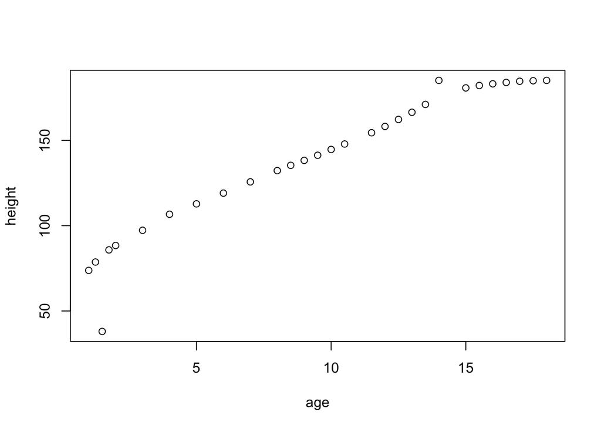

```r
plot(age, foo[1, ], ylab = "height")
```

It is pretty clear looking at the picture which points are the gross errors. But can we get statistics to tell us that?

The one thing we know we don’t want to use is the usual sort of linear models (those fit by `lm`) because the “errors” are not normal. We want what is called “robust” or “resistant” regression.

The R command `??robust` turns up the commands `lqs` and `rlm` in the `MASS` (a “recommended” package that comes with every R installation) package and the command `line` in the `stats` package (a core package that comes with every R installation). The `line` function is not going to be helpful because clearly the growth curves curve. So we want to use either `lqs` or `rlm`. Both are complicated. Let us just try `lqs` because it comes first in alphabetical order.

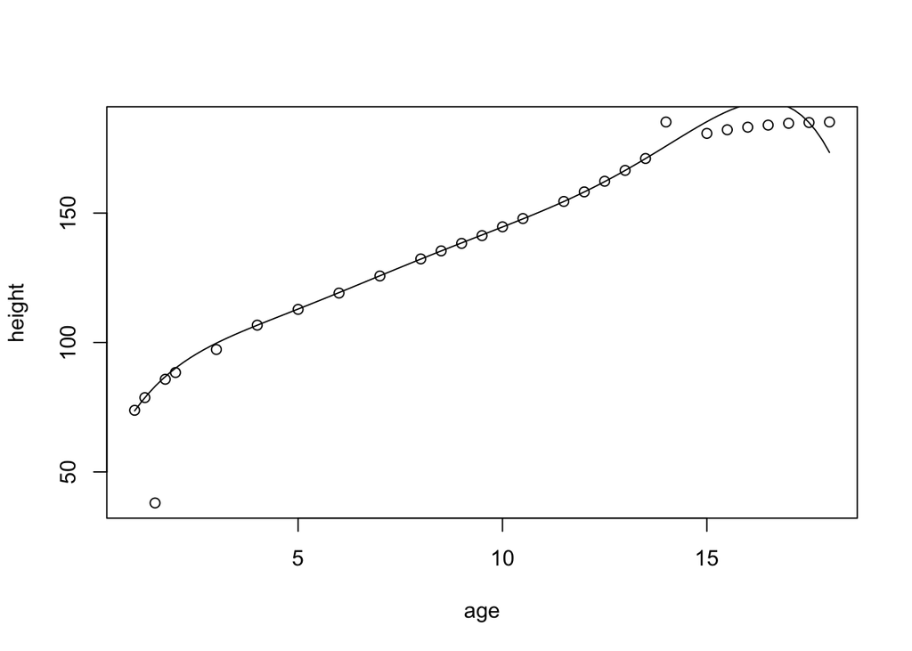

```r
plot(age, foo[1, ], ylab = "height")
library(MASS)
lout <- lqs(foo[1, ] ~ poly(age, degree = 6))
curve(predict(lout, newdata = data.frame(age = x)), add = TRUE)
```

Humph! Doesn’t seem to fit these data well. Try `rlm`.

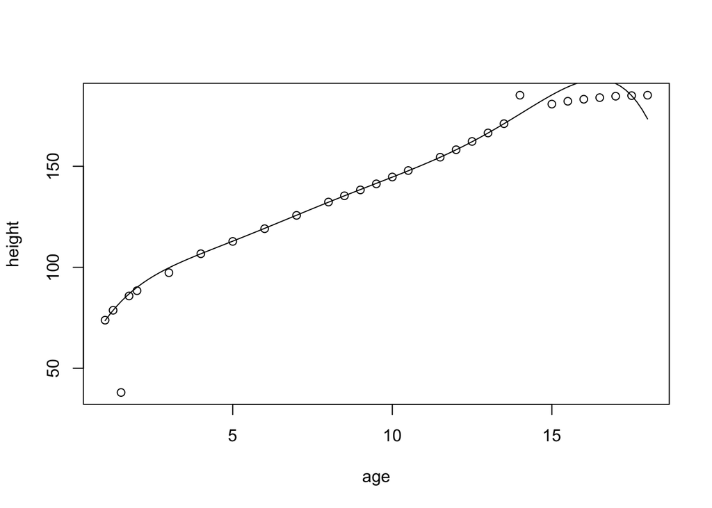

```r
plot(age, foo[1, ], ylab = "height")
rout <- rlm(foo[1, ] ~ poly(age, degree = 6))
curve(predict(lout, newdata = data.frame(age = x)), add = TRUE)
```

Neither of these work because polynomials don’t asymptote. Polynomial regression is a horrible tool for curves that asymptote.

Some googling suggested the function `smooth` in the `stats` package. On reading the documentation for that, it is much more primitive and harder to use. But it may work, so let’s try it.

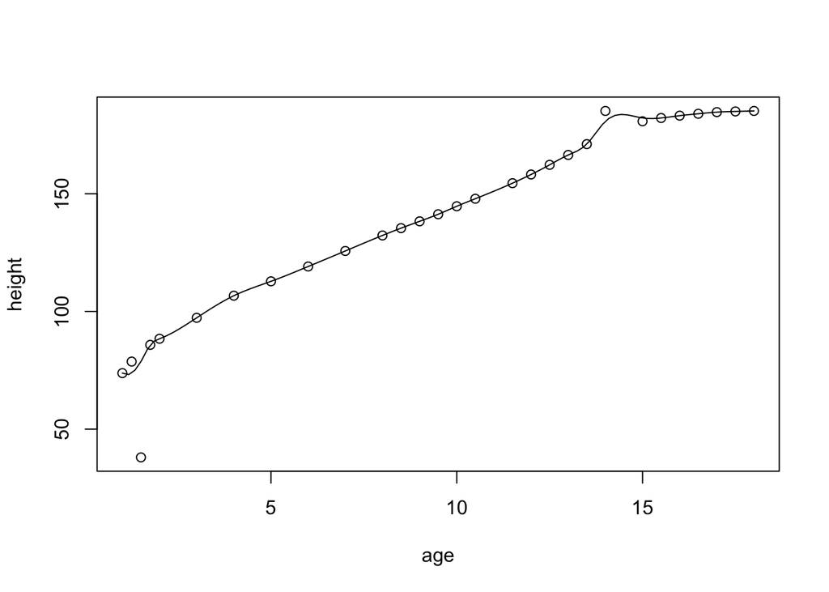

```r
plot(age, foo[1, ], ylab = "height")
y <- foo[1, ]
x <- age[! is.na(y)]
y <- y[! is.na(y)]
sout <- smooth(y)
sally <- splinefun(x, sout)
curve(sally, add = TRUE)
```

Not robust enough.

More googling discovers the [CRAN Task View for Robust Statistical Methods](https://cran.r-project.org/web/views/Robust.html) in which the only mention of splines is the CRAN package `quantreg`. So we try that.

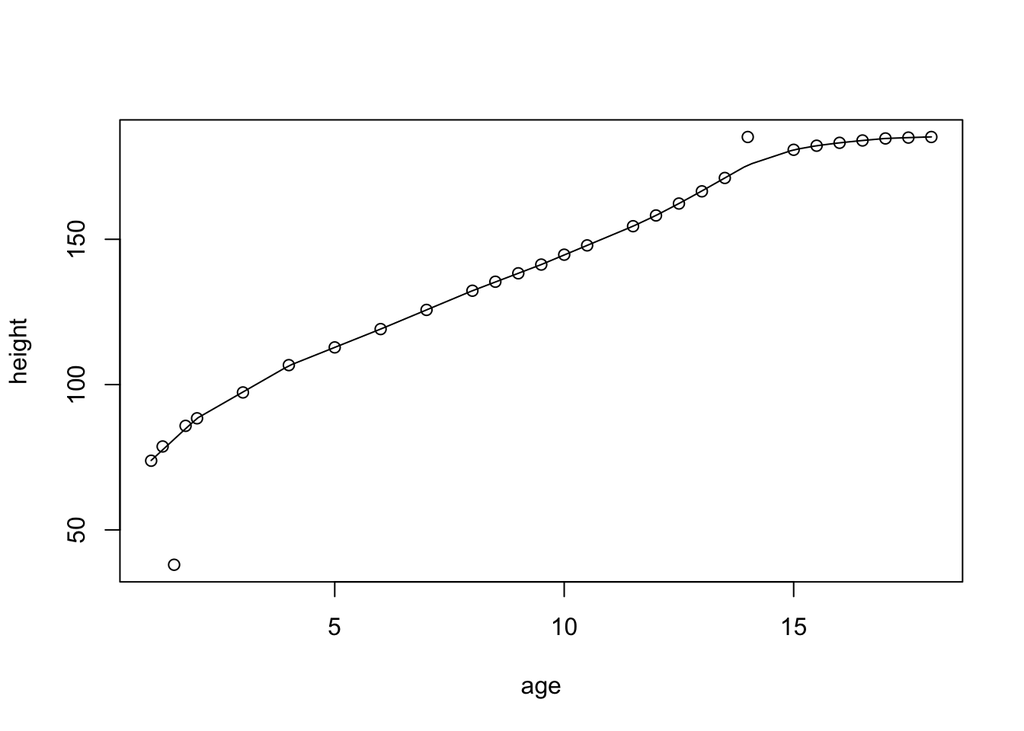

```r
plot(age, foo[1, ], ylab = "height")
library(quantreg)
y <- foo[1, ]
x <- age[! is.na(y)]
y <- y[! is.na(y)]
lambda <- 0.5 # don't repeat yourself (DRY rule)
qout <- rqss(y ~ qss(x, constraint = "I", lambda = lambda))
curve(predict(qout, newdata = data.frame(x = x)),
    from = min(x), to = max(x), add = TRUE)
```

The model fitting function `rqss` and its method for the generic function `predict` were a lot fussier than those for `lqs` and `rlm`. Like with using `smooth` we had to remove the `NA` values by hand rather than just let the model fitting function take care of them (because `rqss` couldn’t take care of them and gave a completely incomprehensible error message). And we had to add optional arguments `from` and `to` to the `curve` function because `predict.rqss` refused to extrapolate beyond the range of the data (this time giving a comprehensible error message).

Anyway, we seem to have got what we want. Now we can compute robust residuals.

```r
rresid <- foo[1, ] - as.numeric(predict(qout, newdata = data.frame(x = age)))
rbind(height = foo[1, ], residual = rresid)
```

```
##                  HT1    HT1.25    HT1.5     HT1.75          HT2   HT3   HT4
## height   73.80000000 78.700000  38.0000 85.8000000 8.840000e+01 97.30 106.7
## residual -0.09275655  1.162221 -43.1828  0.9721773 9.355006e-11 -0.15   0.2
##                    HT5           HT6          HT7          HT8 HT8.5
## height    1.128000e+02  1.191000e+02 1.257000e+02 1.323000e+02 135.4
## residual -2.584244e-10 -2.917716e-09 3.795719e-11 3.125223e-09   0.1
##                    HT9         HT9.5  HT10        HT10.5 HT11        HT11.5
## height    1.383000e+02  1.413000e+02 144.7  1.479000e+02   NA  1.545000e+02
## residual -2.804541e-09 -5.930048e-09   0.1 -8.265033e-11   NA -1.577405e-10
##                  HT12        HT12.5        HT13        HT13.5       HT14 HT14.5
## height    1.58200e+02  1.623000e+02 166.5000000  1.711000e+02 185.200000     NA
## residual -1.25624e-11 -1.904255e-12  -0.1302751 -2.606271e-11   9.630275     NA
##                  HT15       HT15.5          HT16        HT16.5          HT17
## height   1.808000e+02  1.82200e+02  1.832000e+02  1.840000e+02  1.847000e+02
## residual 4.263256e-12 -1.29603e-11 -3.728928e-11 -5.570655e-12 -4.279173e-10
##                HT17.5         HT18
## height   185.00000000 185.20000000
## residual   0.01642436  -0.03749881
```

The robust residuals calculated this way are all small except for the two obvious gross errors. The only one large in absolute value (except for the gross errors) is at the left end of the data, and this is not surprising. All smoothers have trouble at the ends where there is only data on one side to help.

In the fitting we had to choose the `lambda` argument to the `qss` function by hand (because that is what the help page `?qss` says to do), and it did not even tell us whether large `lambda` means more smooth or less smooth. But with some help from what `lambda` does to the residuals, we got a reasonable choice (and perhaps a lot smaller would also do, but we won’t bother with more experimentation).

So let us apply this operation to all the data.

```r
resid <- apply(foo, 1, function(y) {
    x <- age[! is.na(y)]
    y <- y[! is.na(y)]
    qout <- rqss(y ~ qss(x, constraint = "I", lambda = lambda))
    y - as.numeric(predict(qout, newdata = data.frame(x = age)))
})
```

```
## Error in predict.qss1(qss, newdata = newd, ...): no extrapolation allowed in predict.qss
```

```r
dim(foo)
```

```
## [1] 93 31
```

```r
dim(resid)
```

[output not shown]

Didn’t work. We forgot about `predict.rqss` not wanting to predict beyond the range of the data (here beyond the range of `x` which is the ages for which data `y` are not `NA`). We’re going to have to be trickier.

```r
resid <- apply(foo, 1, function(y) {
    x <- age[! is.na(y)]
    y <- y[! is.na(y)]
    qout <- rqss(y ~ qss(x, constraint = "I", lambda = lambda))
    pout <- as.numeric(predict(qout, newdata = data.frame(x = x)))
    rout <- rep(NA, length(age))
    rout[match(x, age)] <- y - pout
    return(rout)
})
```

```
## Warning in rq.fit.sfnc(x, y, tau = tau, rhs = rhs, control = control, ...): tiny diagonals replaced with Inf when calling blkfct
```

I seem to recall not getting this message when `lambda` was larger. Try that.

```r
lambda <- 0.6
resid <- apply(foo, 1, function(y) {
    x <- age[! is.na(y)]
    y <- y[! is.na(y)]
    qout <- rqss(y ~ qss(x, constraint = "I", lambda = lambda))
    pout <- as.numeric(predict(qout, newdata = data.frame(x = x)))
    rout <- rep(NA, length(age))
    rout[match(x, age)] <- y - pout
    return(rout)
})
dim(foo)
```

```
## [1] 93 31
```

```r
dim(resid)
```

```
## [1] 31 93
```

As discussed in the [section about `sweep` in the course notes on matrices](http://www.stat.umn.edu/geyer/3701/notes/array.html#applying-functions-that-return-vectors), sometimes `apply` returns the transpose of what you want.

```r
resid <- t(resid)
```

Now we need to select a cutoff

```r
range(resid, na.rm = TRUE)
```

```
## [1] -89.25433 624.90000
```

```r
stem(resid)
```

```
##
##   The decimal point is 2 digit(s) to the right of the |
##
##   -0 | 9877655555
##   -0 | 44444443333211111111111111111111111111111111111111111111110000000000+1280
##    0 | 00000000000000000000000000000000000000000000000000000000000000000000+1328
##    0 | 7999
##    1 | 00000000000000000000000
##    1 | 8888
##    2 |
##    2 | 777
##    3 | 1
##    3 | 666
##    4 | 4
##    4 | 5555
##    5 | 44
##    5 |
##    6 | 2
```

That didn’t show much.

```r
bigresid <- abs(as.vector(resid))
bigresid <- bigresid[bigresid > 1]
stem(log10(bigresid))
```

```
##
##   The decimal point is 1 digit(s) to the left of the |
##
##    0 | 000001112222344445556666788899901111222335555555688999
##    2 | 00022233466678822335677
##    4 | 01224581247
##    6 | 36334
##    8 | 0180222333444444455555556666666777777777778888888889999999999999999
##   10 | 0000000011111111234581
##   12 | 2245
##   14 | 233333055567
##   16 | 45556633
##   18 | 055615556999
##   20 | 00000000000000000000
##   22 | 5666
##   24 | 3339666
##   26 | 4555533
##   28 | 0
```

That is still confusing. I had hoped there would be an obvious separation between small OK residuals (less than 1, which is what we have already removed) and the big bad residuals. But it seems to be a continuum. Let us decide that all of the residuals greater than 0.8 on the log scale, which is $10^{0.8} = 6.3095734$ without logs are bad.

```r
outies <- log10(abs(resid)) > 0.8
outies[is.na(outies)] <- FALSE
foo[outies] <- NA
```

And now we should redo our whole analysis above and see how big our problems still are.

```r
qux <- NULL
for (i in 1:nrow(foo)) {
    x <- foo[i, ]
    x <- x[! is.na(x)]
    d <- diff(x)
    jj <- which(d <= -0.2)
    for (j in jj) {
        below <- if (j - 1 >= 1) x[j - 1] else NA
        above <- if (j + 2 <= length(x)) x[j + 2] else NA
        qux <- rbind(qux, c(i, below, x[j], x[j + 1], above))
    }
}
qux
```

```
##           HT16 HT16.5  HT17 HT17.5
##  [1,]  2 177.3  177.6 177.3  177.0
##  [2,]  2 177.6  177.3 177.0  177.0
##  [3,] 10 164.2  164.6 163.9  165.0
##  [4,] 19 172.2  172.3 171.2  172.5
##  [5,] 21 173.8  175.0 174.7  176.1
##  [6,] 28 176.1  178.3 177.9  178.2
##  [7,] 34 161.9  161.9 161.7  161.9
##  [8,] 35 164.4  165.8 164.9     NA
##  [9,] 36 163.0  163.4 163.1  163.0
## [10,] 56 163.6  165.3 164.5  164.4
## [11,] 56 164.4  164.3 164.1  164.0
## [12,] 60 171.5  171.4 171.2     NA
## [13,] 62 180.4  180.4 180.2  180.5
## [14,] 63 166.8  168.9 168.2  168.2
## [15,] 68 161.0  161.5 161.0  161.8
## [16,] 68 161.0  161.8 161.6     NA
## [17,] 74  78.2   84.2  78.0   88.4
## [18,] 78 156.0  157.1 156.5     NA
```

Some of these look quite confusing. It is not clear what is going on. Let’s stop here, even though we are not completely satisfied. This is enough time spent on this one issue on a completely made up example.

### 3.2.5 Codes

We still have to figure out what `SEX == 1` and `SEX == 2` mean. And, wary of different sites doing different things, let us look at this per site. There should be height differences at the largest age recorded.

```r
maxht <- apply(foo, 1, max, na.rm = TRUE)
sitesex <- with(growth, paste(SITE, SEX))
unique(sitesex)
```

```
## [1] "A 1" "A 2" "B 1" "B 2" "C 1" "C 2" "D 1" "D 2"
```

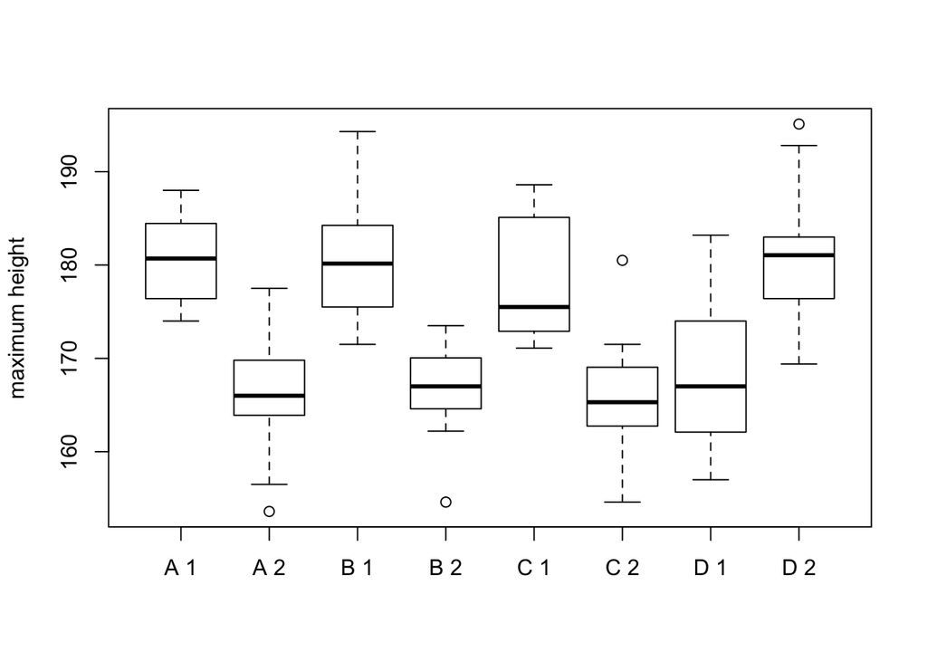

```r
boxplot(split(maxht, sitesex), ylab = "maximum height")
```

So we see another problem. Sites A, B, and C coded the taller sex (male, presumably) as 1, but site D coded them as 2. So we have to fix that.

```r
growth$SEX[growth$SITE == "D"] <- 3 - growth$SEX[growth$SITE == "D"]
sort(unique(growth$SEX))
```

```
## [1] 1 2
```

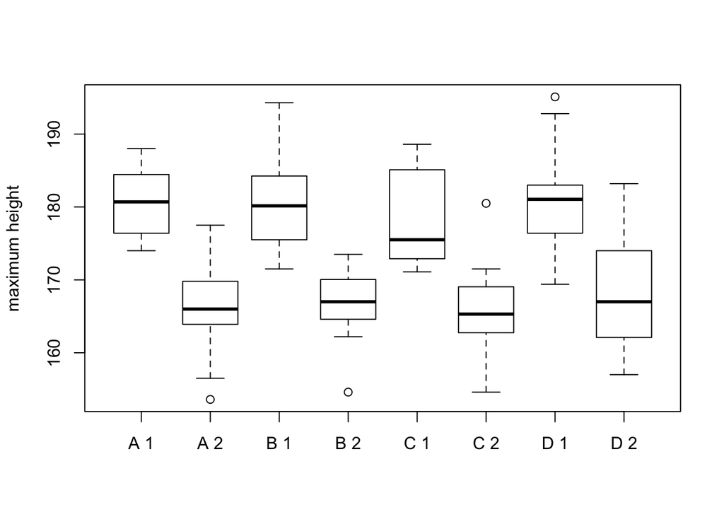

```r
sitesex <- with(growth, paste(SITE, SEX))
boxplot(split(maxht, sitesex), ylab = "maximum height")
```

Looks OK now.

### 3.2.6 Summary

Finding errors in data is really, really hard. But it is essential.

Our example was hard, we still aren’t sure we fixed all the errors. And I cheated. I put the errors in the data in the first place, and then I went and found them (or most of them — it is just impossible to tell whether some of the data entry errors that result in small changes are errors or not).

This example would have been much harder if I did not know what kinds of errors were in the data.

# 4 Data Scraping

One source of data is the World Wide Web. In general, it is very hard to read data off of web pages. But there is a lot to data there, so it is very useful.

The language HTML in which web pages are coded, is not that easy to parse automatically. There is a CRAN package `XML` that reads and parses XML data including HTML data. But I have found it so hard to use that I can’t actually use it (just not enough persistence, I’m sure).

Except there is one function in that package that is easy to use, so we will just illustrate that. The R function `readHTMLTable` in the R package `XML` finds all the HTML tables in a web page and turns each one into an R data frame. It returns a list, each element of which is one table in the web page.

Let’s try it. For example we will use http://www.wcha.com/women/standings.php, which is the standings for the conference that Golden Gopher Womens’s Hockey is in.

```r
library(XML)
foo <- readHTMLTable("http://webcache.googleusercontent.com/search?q=cache:BAFQwYakd1cJ:www.wcha.com/women/standings/index.php+&cd=1&hl=en&ct=clnk&gl=us",
    stringsAsFactors = FALSE)
length(foo)
```

```
## [1] 2
```

We got two tables, and looking at the web page we see two tables, the main standings and the head-to-head table.

```r
foo[[1]]
```

```
##         V1                           V2         V3 V4      V5   V6   V7   V8
## 1 Position                         Team Conference    Overall <NA> <NA> <NA>
## 2      PTS                           GP          W  L       T 3/SW   GF   GA
## 3        1         Wisconsin\n  Badgers         56 24      17    4    3    2
## 4        2  Minnesota\n  Golden Gophers         54 24      17    5    2    1
## 5        3       Ohio State\n  Buckeyes         46 24      13    6    5    2
## 6        4 Minnesota Duluth\n  Bulldogs         41 24      11    8    5    3
## 7        5     Bemidji State\n  Beavers         29 24       9   13    2    0
## 8        6 Minnesota State\n  Mavericks         19 24       4   16    4    3
## 9        7   St. Cloud State\n  Huskies          7 24       2   21    1    0
##     V9  V10  V11  V12  V13  V14  V15  V16
## 1 <NA> <NA> <NA> <NA> <NA> <NA> <NA> <NA>
## 2         W    L    T   GF   GA <NA> <NA>
## 3   97   48        28    5    3  160   62
## 4   86   40        27    6    3  140   61
## 5   81   56        24    8    6  121   82
## 6   69   60        18   12    6   99   81
## 7   48   68        16   18    3   71   91
## 8   40   83        11   20    6   71  108
## 9   32   98         6   25    4   62  122
```

That didn’t work as nicely as it should have, but we did get the data. Try 2.

```r
#foo <- readHTMLTable("",
#    stringsAsFactors = FALSE, header = TRUE)
#foo[[1]]
```

That didn’t work any better. The problem is that this web site uses really crufty HTML. It doesn’t tell us which are the headers, the way HTML has been able to do for at least a decade. So we just have to look at it and fix it up “by hand” (in R).

```r
foo <- foo[[1]]
fooname <- foo[1, ]
foobody <- foo[1 + 1:8, ]
fooname
```

```
##         V1   V2         V3 V4      V5   V6   V7   V8   V9  V10  V11  V12  V13
## 1 Position Team Conference    Overall <NA> <NA> <NA> <NA> <NA> <NA> <NA> <NA>
##    V14  V15  V16
## 1 <NA> <NA> <NA>
```

```r
foobody
```

```
##    V1                           V2 V3 V4 V5   V6 V7 V8 V9 V10 V11 V12 V13 V14
## 2 PTS                           GP  W  L  T 3/SW GF GA      W   L   T  GF  GA
## 3   1         Wisconsin\n  Badgers 56 24 17    4  3  2 97  48      28   5   3
## 4   2  Minnesota\n  Golden Gophers 54 24 17    5  2  1 86  40      27   6   3
## 5   3       Ohio State\n  Buckeyes 46 24 13    6  5  2 81  56      24   8   6
## 6   4 Minnesota Duluth\n  Bulldogs 41 24 11    8  5  3 69  60      18  12   6
## 7   5     Bemidji State\n  Beavers 29 24  9   13  2  0 48  68      16  18   3
## 8   6 Minnesota State\n  Mavericks 19 24  4   16  4  3 40  83      11  20   6
## 9   7   St. Cloud State\n  Huskies  7 24  2   21  1  0 32  98       6  25   4
##    V15  V16
## 2 <NA> <NA>
## 3  160   62
## 4  140   61
## 5  121   82
## 6   99   81
## 7   71   91
## 8   71  108
## 9   62  122
```

We see that web site is really crufty in its table coding. The names are off by one. And some of the names are blank, and column 11 in the table is just empty, just there to take up space.

```r
foobody <- foobody[ , -11]
fooname <- fooname[-length(fooname)]
fooname[1] <- "Team"
fooname <- c("Place", fooname)
fooname <- fooname[-11]
names(foobody) <- fooname
foobody
```

```
##   Place                         Team Team Conference    Overall NA NA NA NA NA
## 2   PTS                           GP    W          L  T    3/SW GF GA     W  T
## 3     1         Wisconsin\n  Badgers   56         24 17       4  3  2 97 48 28
## 4     2  Minnesota\n  Golden Gophers   54         24 17       5  2  1 86 40 27
## 5     3       Ohio State\n  Buckeyes   46         24 13       6  5  2 81 56 24
## 6     4 Minnesota Duluth\n  Bulldogs   41         24 11       8  5  3 69 60 18
## 7     5     Bemidji State\n  Beavers   29         24  9      13  2  0 48 68 16
## 8     6 Minnesota State\n  Mavericks   19         24  4      16  4  3 40 83 11
## 9     7   St. Cloud State\n  Huskies    7         24  2      21  1  0 32 98  6
##   NA NA   NA   NA
## 2 GF GA <NA> <NA>
## 3  5  3  160   62
## 4  6  3  140   61
## 5  8  6  121   82
## 6 12  6   99   81
## 7 18  3   71   91
## 8 20  6   71  108
## 9 25  4   62  122
```

Except that is bad because we have duplicate variable names. Looking at the table on the web, we we see we have W, L, T, GF, GA both for play within the conference and for overall (both conference and non-conference games). So we modify the latter.

```r
fooname[duplicated(fooname)] <-
    paste(fooname[duplicated(fooname)], "O", sep = ".")
names(foobody) <- fooname
foobody
```

```
##   Place                         Team Team.O Conference    Overall NA NA.O NA.O
## 2   PTS                           GP      W          L  T    3/SW GF   GA
## 3     1         Wisconsin\n  Badgers     56         24 17       4  3    2   97
## 4     2  Minnesota\n  Golden Gophers     54         24 17       5  2    1   86
## 5     3       Ohio State\n  Buckeyes     46         24 13       6  5    2   81
## 6     4 Minnesota Duluth\n  Bulldogs     41         24 11       8  5    3   69
## 7     5     Bemidji State\n  Beavers     29         24  9      13  2    0   48
## 8     6 Minnesota State\n  Mavericks     19         24  4      16  4    3   40
## 9     7   St. Cloud State\n  Huskies      7         24  2      21  1    0   32
##   NA.O NA.O NA.O NA.O NA.O NA.O
## 2    W    T   GF   GA <NA> <NA>
## 3   48   28    5    3  160   62
## 4   40   27    6    3  140   61
## 5   56   24    8    6  121   82
## 6   60   18   12    6   99   81
## 7   68   16   18    3   71   91
## 8   83   11   20    6   71  108
## 9   98    6   25    4   62  122
```

Better. Ugly, but usable.

# 5 Web Services

Some web sites have APIS that allow computers to talk to them (not just people look at them).

## 5.1 Github Example

Here is an example. It is copied from the vignette `json-apis` for the CRAN package `jsonlite` (for those who don’t know JSON is the most popular data interchange format (for computers to talk to computers)).

```r
library(jsonlite)
foo <- fromJSON("https://api.github.com/users/cjgeyer/repos")
names(foo)
```

```
##  [1] "id"                "node_id"           "name"
##  [4] "full_name"         "private"           "owner"
##  [7] "html_url"          "description"       "fork"
## [10] "url"               "forks_url"         "keys_url"
## [13] "collaborators_url" "teams_url"         "hooks_url"
## [16] "issue_events_url"  "events_url"        "assignees_url"
## [19] "branches_url"      "tags_url"          "blobs_url"
## [22] "git_tags_url"      "git_refs_url"      "trees_url"
## [25] "statuses_url"      "languages_url"     "stargazers_url"
## [28] "contributors_url"  "subscribers_url"   "subscription_url"
## [31] "commits_url"       "git_commits_url"   "comments_url"
## [34] "issue_comment_url" "contents_url"      "compare_url"
## [37] "merges_url"        "archive_url"       "downloads_url"
## [40] "issues_url"        "pulls_url"         "milestones_url"
## [43] "notifications_url" "labels_url"        "releases_url"
## [46] "deployments_url"   "created_at"        "updated_at"
## [49] "pushed_at"         "git_url"           "ssh_url"
## [52] "clone_url"         "svn_url"           "homepage"
## [55] "size"              "stargazers_count"  "watchers_count"
## [58] "language"          "has_issues"        "has_projects"
## [61] "has_downloads"     "has_wiki"          "has_pages"
## [64] "forks_count"       "mirror_url"        "archived"
## [67] "disabled"          "open_issues_count" "license"
## [70] "forks"             "open_issues"       "watchers"
## [73] "default_branch"
```

Hmmmmm. An incredible amount of stuff there, most of which I don’t understand even though I am a long time github user.

But

```r
foo$name
```

```
##  [1] "bar"             "bernor"          "foo"             "gdor"
##  [5] "glmbb"           "glmdr"           "linkingTo"       "mat"
##  [9] "mcmc"            "nice"            "Orientation2018" "polyapost"
## [13] "pooh"            "potts"           "qux"             "rcdd"
## [17] "sped"            "Test"            "trust"           "TSHRC"
## [21] "ump"
```

are the names of my github public repos.

Of course, to do anything nontrivial you have to understand the web service. Read up on their API, and so forth.

The only point we are making here is that CRAN has the packages to support this stuff.

## 5.2 Crandb Example

Here is another example copied from the README at https://github.com/metacran/crandb.

```r
foo <- fromJSON("http://crandb.r-pkg.org/-/latest")
class(foo)
```

```
## [1] "list"
```

```r
length(foo)
```

```
## [1] 15541
```

```r
class(foo[[1]])
```

```
## [1] "list"
```

```r
names(foo[[1]])
```

```
##  [1] "Package"          "Type"             "Title"            "Version"
##  [5] "Date"             "Author"           "Maintainer"       "Description"
##  [9] "License"          "Depends"          "Suggests"         "NeedsCompilation"
## [13] "Packaged"         "Repository"       "Date/Publication" "crandb_file_date"
## [17] "date"             "releases"
```

Woof! 15541 CRAN packages as of the last time this handout was rendered.

Here’s the ones on which I am an author (I apologize for tooting my own horn).

```r
aut <- sapply(foo, function(x) x$Author)
nam <- sapply(foo, function(x) x$Package)
nam[grep("Geyer", aut)]
```

```
##                 aster                aster2        fuzzyRankTests
##               "aster"              "aster2"      "fuzzyRankTests"
##                 glmbb                  glmm                   krm
##               "glmbb"                "glmm"                 "krm"
##                  mcmc                  nice   partitionComparison
##                "mcmc"                "nice" "partitionComparison"
##             polyapost                  pooh                 potts
##           "polyapost"                "pooh"               "potts"
##                  rcdd               sfsmisc                  sped
##                "rcdd"             "sfsmisc"                "sped"
##                 trust                 TSHRC                   ump
##               "trust"               "TSHRC"                 "ump"
```

Everything appears twice because the vectors have names and the names are the same as the values for the vector `nam`.

```r
as.vector(nam[grep("Geyer", aut)])
```

```
##  [1] "aster"               "aster2"              "fuzzyRankTests"
##  [4] "glmbb"               "glmm"                "krm"
##  [7] "mcmc"                "nice"                "partitionComparison"
## [10] "polyapost"           "pooh"                "potts"
## [13] "rcdd"                "sfsmisc"             "sped"
## [16] "trust"               "TSHRC"               "ump"
```

drops the names.

# 6 Databases

## 6.1 SQL Databases

A large amount of the world’s data is stored in *relational database management systems* (RDBMS) ([Wikipedia page for that](https://en.wikipedia.org/wiki/List_of_relational_database_management_systems)) like Oracle, MySQL, Microsoft SQL Server, PostgreSQL and IBM DB2.

The “computer language” of those thingummies is SQL (structured query language) with “computer language” in scare quotes, because it isn’t a complete computer language.

R can talk to an RDBMS via the CRAN package `DBI` (which we won’t illustrate).

Instead we will use the package `RSQLite` which talks to a very different kind of SQL database, called `SQLite`.

Oracle, Microsoft SQL Server, IBM DB2 are very expensive and require a lot of staff to support. The U uses Oracle, although we say we use PeopleSoft, a company which was long ago bought by Oracle. When you register for classes or get your grades. That’s PeopleSoft (Oracle). MySQL is nominally free software but is owned by Oracle, and just to be safe, there are two free software clones of it (MariaDB and Percona). PostgreSQL is free software. None of these can be set up by ordinary users.

In contrast, SQLite is just a program. Any user can install it and use it. The CRAN package `RSQLite` has the `SQLite` RDBMS built in. So anyone can play with SQL and with R talking to RDBMS.

Once you get what you are trying to do working in `RSQLite`, you shouldn’t have too much trouble getting your R code to talk to another RDBMS via `DBI` except, of course, that an RDBMS like the U’s Oracle database won’t talk to just any program. It’s all locked up behind firewalls and other security thingummies. But assuming you do have permission to query the database using a computer, then you should be able do it using R.

Let’s try to put our last example into an SQL database.

An SQL database has one or more tables that are more or less like data frames in R. The columns are variables and the rows (SQL calls them tuples) are individuals (cases). Certain columns are special (primary and secondary keys, but we won’t worry about that yet).

Since, we have to put data in tables, we have a problem. The reason `fromJSON` did not return a data frame in the second example (Section 5.2 above) like it did in the first example (Section 5.1 above) is that the items in an R package description can vary.

```r
foo.nam <- lapply(foo, names)
foo.nam.union <- Reduce(union, foo.nam)
foo.nam.intersection <- Reduce(intersect, foo.nam)
foo.nam.union
```

```
##   [1] "Package"                          "Type"
##   [3] "Title"                            "Version"
##   [5] "Date"                             "Author"
##   [7] "Maintainer"                       "Description"
##   [9] "License"                          "Depends"
##  [11] "Suggests"                         "NeedsCompilation"
##  [13] "Packaged"                         "Repository"
##  [15] "Date/Publication"                 "crandb_file_date"
##  [17] "date"                             "releases"
##  [19] "Imports"                          "Encoding"
##  [21] "LazyData"                         "RoxygenNote"
##  [23] "VignetteBuilder"                  "MD5sum"
##  [25] "URL"                              "Authors@R"
##  [27] "BugReports"                       "Contact"
##  [29] "SystemRequirements"               "LinkingTo"
```

[output cut: 46 more lines]

```r
foo.nam.intersection
```

```
##  [1] "Package"          "Title"            "Version"          "Author"
##  [5] "Maintainer"       "Description"      "License"          "crandb_file_date"
##  [9] "date"             "releases"
```

So the only table we could make for all the packages, would have only the `foo.nam.intersection` variables unless we allowed for missing values. SQL does have a missing value called `NULL`. This is unlike R’s `NULL` and more like R’s `NA`. But let’s not try that right away.

Are all of these fields scalars?

```r
foo[[1]][foo.nam.intersection]
```

```
## $Package
## [1] "A3"
##
## $Title
## [1] "Accurate, Adaptable, and Accessible Error Metrics for Predictive\nModels"
##
## $Version
## [1] "1.0.0"
##
## $Author
## [1] "Scott Fortmann-Roe"
##
## $Maintainer
## [1] "Scott Fortmann-Roe <scottfr@berkeley.edu>"
##
## $Description
## [1] "Supplies tools for tabulating and analyzing the results of predictive models. The methods employed are applicable to virtually any predictive model and make comparisons between different methodologies straightforward."
##
## $License
## [1] "GPL (>= 2)"
##
## $crandb_file_date
## [1] "2015-08-16 17:08:22"
##
## $date
## [1] "2015-08-16T23:05:52+00:00"
##
## $releases
## list()
```

Not `releases`. So forget that. Also two dates seems unnecessary. Make a data frame.

```r
foo.nam.intersection <- foo.nam.intersection[foo.nam.intersection != "releases"]
foo.nam.intersection <- foo.nam.intersection[foo.nam.intersection != "date"]

bar <- list()
for (n in foo.nam.intersection)
    bar[[n]] <- as.vector(sapply(foo, function(x) x[[n]]))
names(bar)
```

```
## [1] "Package"          "Title"            "Version"          "Author"
## [5] "Maintainer"       "Description"      "License"          "crandb_file_date"
```

```r
names(bar)[8] <- "Date"
bar <- as.data.frame(bar, stringsAsFactors = FALSE)
dim(bar)
```

```
## [1] 15541     8
```

Now we put it in a temporary RSQLite database following the vignette in the package `RSQLite`.

```r
library(DBI)
mydb <- dbConnect(RSQLite::SQLite(), "")
dbWriteTable(mydb, "cran", bar)
```

Now we have an SQL database to play with. To do anything with it, we need to know some SQL. And if we started on that it would be a whole semester learning SQL. There’s a computer science course for that.

So we will just do a simple example.

```r
qux <- dbGetQuery(mydb, "SELECT * FROM cran WHERE Author LIKE '%Geyer%'")
class(qux)
```

```
## [1] "data.frame"
```

```r
names(qux)
```

```
## [1] "Package"     "Title"       "Version"     "Author"      "Maintainer"
## [6] "Description" "License"     "Date"
```

```r
qux$Package
```

```
##  [1] "aster"               "aster2"              "fuzzyRankTests"
##  [4] "glmbb"               "glmm"                "krm"
##  [7] "mcmc"                "nice"                "partitionComparison"
## [10] "polyapost"           "pooh"                "potts"
## [13] "rcdd"                "sfsmisc"             "sped"
## [16] "trust"               "TSHRC"               "ump"
```

## 6.2 NoSQL Databases

A recent development (last 20 years) is so-called noSQL databases. These take a great leap backward in terms of features. But they do so in order to be huge, scaling to the size needed by Google, Amazon, or Facebook.

R can talk to some of these too.

```r
dbnames <- c("CouchDB", "MongoDB", "Cassandra", "Redis", "Dynamo", "HBase")
quux <- list()
for (d in dbnames) {
    query <- paste("SELECT Package FROM cran WHERE Description LIKE '%", d,
        "%' OR Title LIKE '%", d, "%'", sep = "")
    quux[[d]] <- as.vector(dbGetQuery(mydb, query))
}
quux
```

```
## $CouchDB
##     Package
## 1   couchDB
## 2     nodbi
## 3 R4CouchDB
## 4      sofa
##
## $MongoDB
##            Package
## 1         GeoMongo
## 2          jSonarR
## 3        mongolite
## 4            nodbi
## 5            Rpoet
## 6 shinyEventLogger
##
## $Cassandra
##      Package
## 1 RCassandra
##
## $Redis
##        Package
## 1      doRedis
## 2         eGST
## 3      fhidata
## 4        gnorm
## 5      ICD10gm
## 6         ideq
## 7        nodbi
## 8    RcppRedis
## 9       redist
## 10       redux
## 11 ropercenter
## 12      rredis
##
## $Dynamo
##         Package
## 1    awsjavasdk
## 2          paws
## 3 paws.database
##
## $HBase
##     Package
## 1    implyr
## 2    osmose
## 3 rfishbase
```

But doing an example of any of these is far beyond the scope of this course (and what the instructor knows).

## 6.3 Clean Up

One last thing. Close the database connection.

```r
dbDisconnect(mydb)
```